# Pablo AI home exercise

Pablo Daniel Jelsky

22/02/2021

# **Exercise on target tracking**

## Links related to this exercise

- [Digital Elevation Model (DEM)](https://en.wikipedia.org/wiki/Digital_elevation_model)
- [Geospatial Data Abstraction Library (GDAL)](https://en.wikipedia.org/wiki/GDAL)
- GeoTIFF

## Task objective: double tracking

- The idea of this home exercise is to create an algorithm that allows the continuous tracking after the person - “target” - by a couple of agents
- Given a DSM (Digital Surface Model) building’s map - 100 [m] x 100 [m] matrix ????
- Given the “target” maximum speed as 1 meter/second in a not known in advance route. The “target movement is limited only to”ground" level
- Given the “agents” speed as 2 meters/second, and are only allowed to be as close as 10 meters (no less than this) from the “target”. The “agents” movement is also limited to “ground” level
- The home exercise objective is to create an algorithm that once in a second, gives us the “target” and “agents” position given the limitations above, and issues instructions to the “agents” next movement in order that at least one of the “agents” could have “eye-contact” as much as possible with the “target”

## Clarifications from Yair email (2021-02-21)

- Work with the DSM with the size ‘as is’ 351x201 pixels
- One pixel equals to one meter
- The target is supposed to have constant rate (1 meter/second) and could NOT stop
- The agent could also stop or up to 2 meters/second (0 meters/second, 1 meter/second, 2 meters/second)
- Starting points for the target and agents could be in every place but NOT in a “obstacle” level (NOT “ground” level)
- The agents will have LOS with the “target” in the first simulation cycle

## Development steps

```r
# Clear the global work-space
rm (list = ls())
# Define global variables
ROOT_DIRECTORY                        = "/home/pablo/Documents/Software Engineering/AI home exercise/Input/"
DSM_FILE                              = "cage6.tif"
TARGET_SPEED_IN_M_SEC                 = 1
AGENT_SPEED_IN_M_SEC                  = 2
TARGET_AGENT_MINIMUM_DISTANCE_M       = 10
```

```r
# dplyr library - A grammar of data manipulation, providing a consistent set of verbs that help you solve the most common data manipulation challenges
suppressPackageStartupMessages(library(dplyr))
# ggplot2 library - A tool to create elegant data visualizations using the grammar of graphics
suppressPackageStartupMessages(library(ggplot2))
library(viridis)
# A package providing classes and methods for spatial data: points, lines, polygons and grids, needed by raster library
suppressPackageStartupMessages(library(sp))
# library used to work with raster data
suppressPackageStartupMessages(library(raster))
# GDAL is a translator library for raster and vector geospatial data formats that is released under an X/MIT style Open Source License by the Open Source Geospatial Foundation. As a library, it presents a single raster abstract data model and single vector abstract data model to the calling application for all supported formats.
# This library is the port to R of the GDAL library (to be used for GeoTIFFs and oTher core GIS functions)
library(rgdal)
# Set the working directory
setwd (ROOT_DIRECTORY) #  because we are using knitr, then we need also the following solution
require("knitr")
opts_knit$set(root.dir = ROOT_DIRECTORY)

# view raster attributes
DsmOriginalRaster   <- raster(DSM_FILE)
GDALinfo(DSM_FILE)
```

```
## rows        201
## columns     351
## bands       1
## lower left origin.x        713272.9
## lower left origin.y        3637192
## res.x       0.1
## res.y       0.1
## ysign       -1
## oblique.x   0
## oblique.y   0
## driver      GTiff
## projection  +proj=utm +zone=36 +datum=WGS84 +units=m +no_defs
## file        cage6.tif
## apparent band summary:
##    GDType hasNoDataValue NoDataValue blockSize1 blockSize2
## 1 Float64          FALSE           0         32         48
## apparent band statistics:
##          Bmin       Bmax Bmean Bsd
## 1 -4294967295 4294967295    NA  NA
## Metadata:
## AREA_OR_POINT=Point
## TIFFTAG_SOFTWARE=MATLAB 8.6, Mapping Toolbox 4.2
```

```r
# Convert to matrix to start working
DsmOriginalMatrix   <- getValues(DsmOriginalRaster, format = "matrix")
# Get useful variables
DsmNumberOfColumns  <- ncol(DsmOriginalMatrix)
DsmNumberOfRows     <- nrow(DsmOriginalMatrix)
sprintf("Info for %s DSM file: %d rows x %d columns", DSM_FILE, DsmNumberOfRows, DsmNumberOfColumns)
```

```
## [1] "Info for cage6.tif DSM file: 201 rows x 351 columns"
```

## Visual simulation

### Useful links

- [Finding Shortest Path in the Plane with Obstacles](https://www.codingame.com/playgrounds/39380/finding-shortest-path-in-the-plane-with-obstacles)
- [A* Algorithm: How to find the shortest path between two points](https://medium.com/analytics-vidhya/a-algorithm-how-to-find-the-shortest-path-between-two-points-767c8a76376)
- [Shortest distance between two cells in a matrix or grid](https://www.geeksforgeeks.org/shortest-distance-two-cells-matrix-grid/)

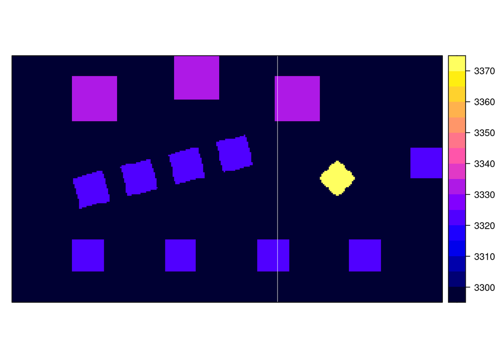

```r
# Show the DSM (Digital Surface Model) map in Python or Matlab (in this case in R)
spplot(DsmOriginalRaster)
```

```r
# Target
## Create "target" route given beginning and ending location __GoFromAtoB(OriginalDSMFile, LocationA, LocationB, VisibilityInMeters)__

GoFromAtoB = function(OriginalDSMFile, LocationA, LocationB, VisibilityInMeters)
{
  return (NewDSMFileWithRouteFromAtoB)
}

## Show "target" progress over time in DSM map
TargetArrivedToDestination  <- FALSE
SimulationTimeInSeconds     <- 0
### Loop
while (TargetArrivedToDestination == FALSE) {

  if (SimulationTimeInSeconds >= 60) {
    TargetArrivedToDestination  <- TRUE
  }
  else {
    print(sprintf("Time %d    Target position (x,y)", SimulationTimeInSeconds))
    SimulationTimeInSeconds     <- SimulationTimeInSeconds + 1
  }
}
```

```
## [1] "Time 0    Target position (x,y)"
## [1] "Time 1    Target position (x,y)"
## [1] "Time 2    Target position (x,y)"
## [1] "Time 3    Target position (x,y)"
## [1] "Time 4    Target position (x,y)"
## [1] "Time 5    Target position (x,y)"
## [1] "Time 6    Target position (x,y)"
## [1] "Time 7    Target position (x,y)"
## [1] "Time 8    Target position (x,y)"
## [1] "Time 9    Target position (x,y)"
## [1] "Time 10    Target position (x,y)"
## [1] "Time 11    Target position (x,y)"
## [1] "Time 12    Target position (x,y)"
## [1] "Time 13    Target position (x,y)"
## [1] "Time 14    Target position (x,y)"
```

[output cut: 45 more lines]

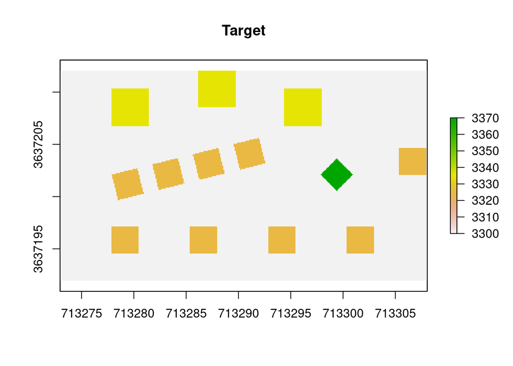

```r
DsmTargetRasterLayerBuildings   <- DsmOriginalRaster
DsmTargetRasterLayerTarget      <- list("Target", c(180500,329900), "0")
plot(DsmTargetRasterLayerBuildings, main = "Target")
```

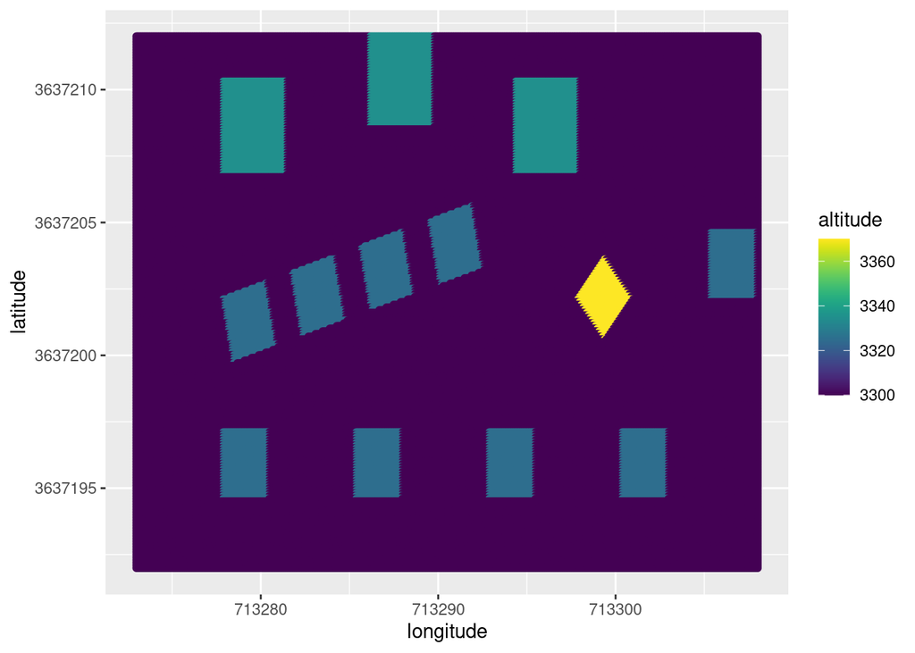

```r
# turn the data into a spatial data frame
#DsmTargetRasterLayerBuildings_df <- SpatialLinesDataFrame(DsmTargetRasterLayerBuildings)
#tidy(coastlines_sim2_df)

## Convert it to a dataframe
DsmTargetRasterLayerBuildings_df  <- as.data.frame(DsmTargetRasterLayerBuildings, xy = TRUE)
## Renaming columns
DsmTargetRasterLayerBuildings_df  <- setNames(DsmTargetRasterLayerBuildings_df, c("longitude", "latitude", "altitude"))
# Convert altitude to factor
#DsmTargetRasterLayerBuildings_df$altitude <- as.factor(DsmTargetRasterLayerBuildings_df$altitude)
#factor
#levels(DsmTargetRasterLayerBuildings_df$altitude)
# plot the data
#ggplot() +
#  geom_path(data = DsmTargetRasterLayerBuildings_df, aes(x = longitude, y = latitude, color = altitude)) +
#  geom_point() +
#  labs(title = "Target"
plot <- ggplot(DsmTargetRasterLayerBuildings_df, aes(x = longitude, y = latitude, color = altitude))
plot <- plot + geom_point() + scale_color_viridis()
print (plot)
```

```r
#  geom_path(data = DsmTargetRasterLayerBuildings_df, aes(x = long, y = lat, group = group)) +
#  labs(title = "Target")
# Followers
## Show "followers" progress over time in DSM map
# Line of sight (LOS)
## Show line of sight between the "follower" and the "target" if the LOS exists
```

## Help tools for the solution

### Line of sight (LOS) map

- Map for every pixel at “ground” level, all the pixels that are inside the LOS
- Take a few locations in the DSM and show the results in it

## Working with “only” one agent

- Write a function that will return the progress command to the agent given his and the “target” current locations: **CalculateNextLocation(TargetCurrentLocation, FollowerCurrentLocation)**
- Progress command will take in account the potential next location of both the “target” and the “agent” so that will have LOS between “agent” and “target” as much as possible time

```r
CalculateNextLocation = function(TargetCurrentLocation, AgentCurrentLocation)
{
  return (AgentNextLocation)
}
```

## Working with a couple of agents - Central control

- Like in the previous section, but the function should give guidance to both agent: **CalculateNextLocation2(TargetCurrentLocation, AgentCurrentLocation)**
- It is desirable that there will be some kind of coordination between both commands so that one agent will complement the other

## Working with a couple of agents - Distributed control

- Write a function that will return the progress command to a **single** agent given his, the second agent and the “target” current locations: **CalculateNextLocation3(TargetCurrentLocation, OtherAgentCurrentLocation, AgentCurrentLocation)**
- The functions (for each agent) are not related between them
- The functions will give guidance every 2 seconds, once the function will work with agent1, and the next second will work with agent2, therefore the function(s) won’t work with the same input
- It is desirable that there will be some kind of coordination between both commands so that one agent will complement the other

# Solution

## 1.1) Display the DSM file in Python / Matlab (in this case as .png file)

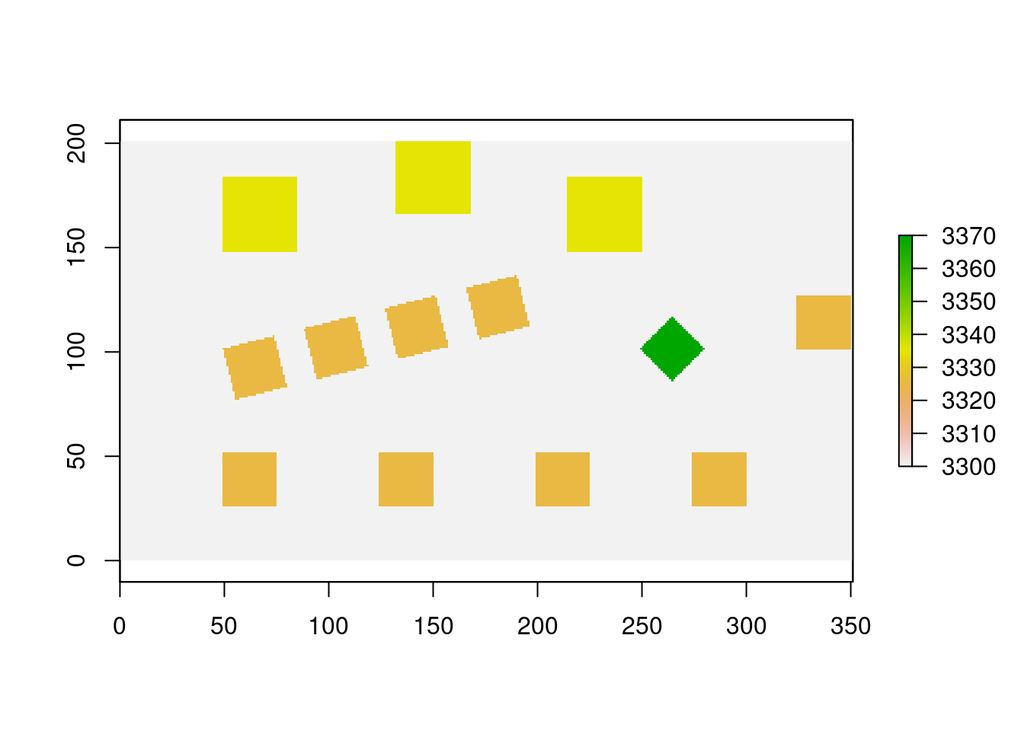

```r
# view raster attributes
DsmTestRaster   <- raster("/home/pablo/Documents/Software Engineering/AI home exercise/Solution/output/1_2 2_DsmOriginalFile Target.tif")
plot(DsmTestRaster)
```

## 1.2.2) Display “target” path progress over time on map

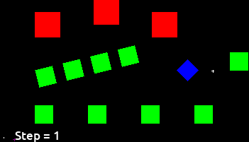

## Bonus) Display “agent alone” path progress over time on map (to show different A* configuration)

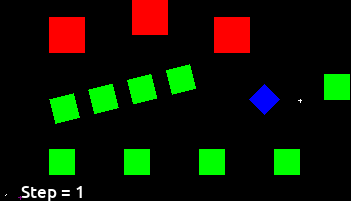

## 2.2) Take a number of DSM locations and display the LOS between them

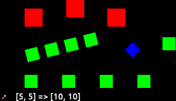

FPS = 1

## Algorithm for lonely agent following target

- Build a list of possible NEXT locations both for agent and target with SwissArmyKnife.PossibleMovements() given as input parameters: type of movement of person (1 meter constant, up to two meters, etc), current location and DSM map info, and receiving as output the list of possible NEXT movements
- Filter from this list only the locations that have LOS between agent and target and also that will be at a minimum distance of the ALLOWED distance (10 meters in this case) with SwissArmyKnife.PossibleLineOfSightLocations() given as input parameters: list of possible NEXT movements from both agent and target, DSM map info, and minimum ALLOWED distance between both agent and target. The output received from this function is a new list having all the possible NEXT movements for agent, that will have LOS with target caring for the minimum allowed distance
- Rank the last list by minimum and maximum distance from agent to target, quantity of potential LOS with target, and distance to obstacle with the following functions: SwissArmyKnife.Ranking(). The idea of ranking, is that for all the potential movements, there will be a minimum and maximum (range) for each one of these variables. And therefore we will rank from 0% to 100%, according to where specific element is in the range of the possible NEXT movements.
- Once ranked these variables, we could use another function: SwissArmyKnife.RankingOrder() that will give a specific relative “weight” for each one of these variables: minimum distance from agent to target maximum distance from agent to target quantity of possible LOS situations minimum distance to obstacle
- This function will order this list according to our requirements
- After a few verifications it has been seen, that the distance to obstacle should be with high relative weight, but once the distance between target and agent is more than 20, then the weight should fall more in the minimum distance to target (in order for the agent to reduce the distance)
- In case of LOS loss, we need to have the last target position seen (as the “target” position), modify temporarily the possibility to stay in place for the agent, so it could move towards the last seen position. Once there is again LOS, we need to bring back the regular configuration, and set the target position as the real target position

## 3) Working with “only” one agent

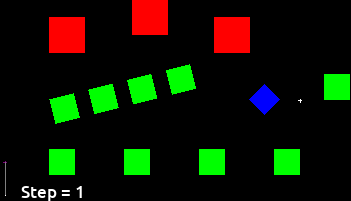

FPS = 10

## Algorithm for two agents following target (centralized control)

- Build a list of possible NEXT locations for both agents and target with SwissArmyKnife.PossibleMovements() given as input parameters: type of movement of person (1 meter constant, up to two meters, etc), current location and DSM map info, and receiving as output the list of possible NEXT movements
- Filter from this list only the locations that have LOS between both agents and target and also that will be at a minimum distance of the ALLOWED distance (10 meters in this case) with SwissArmyKnife.PossibleLineOfSightLocations() given as input parameters: list of possible NEXT movements from both agent and target, DSM map info, and minimum ALLOWED distance between both agent and target. The output received from this function is a new list having all the possible NEXT movements for agent, that will have LOS with target caring for the minimum allowed distance
- Rank the last list by minimum and maximum distance from agent to target, quantity of potential LOS with target, and distance to obstacle with the following functions: SwissArmyKnife.Ranking(). The idea of ranking, is that for all the potential movements, there will be a minimum and maximum (range) for each one of these variables. And therefore we will rank from 0% to 100%, according to where specific element is in the range of the possible NEXT movements.
- Once ranked these variables, we could use another function: SwissArmyKnife.RankingOrder() that will give a specific relative “weight” for each one of these variables: minimum distance from agent to target maximum distance from agent to target quantity of possible LOS situations minimum distance to obstacle distance to opposite location of other agent
- This function will order this list according to our requirements
- After a few verifications it has been seen, that the distance to obstacle should be with high relative weight, but once the distance between target and agent is more than 20, then the weight should fall more in the minimum distance to target (in order for the agent to reduce the distance)
- If both agents have LOS, then the one with more potential movements with LOS to target will be the master
- The slave agent will have, in addition to the regular rankings (like distance to obstacle, distance to target, etc), also the distance to the master agent opposite location (being the central point of this line, the target location)
- The ranking is different depending on the situation, and the kind of agent (master/slave)

- ```
    If agent is master, and the distance to target is more than 20 meters, then in the ranking give preference to potential movements that will reduce the distance between agent and target
  ```

- ```
    If agent is master, and the distance to target is less or equal to 20 meters, then in the ranking give preference to potential movements that will increase the distance between agent and closest obstacle
  ```

- ```
    If agent is slave, and the distance to target is more than 20 meters, then in the ranking give preference to potential movements that will reduce the distance between the slave agent and the opposite location to master agent, and also to target
  ```

- ```
    If agent is slave, and the distance to target is less or equal to 20 meters, then in the ranking give preference to potential movements that will reduce the distance between the slave agent and the opposite location to master agent and increase the distance to closest obstacle
  ```

- ```
    If both agents have lost LOS with target, and the distance to last known target location is more than 20 meters, then in the ranking give preference to potential movements that will reduce the distance between agent and last know target location
  ```

- ```
    If both agents have lost LOS with target, and the distance to last known target location is less or equal than 20 meters, then in the ranking give preference to potential movements that will increase the distance between agent and closest obstacle
  ```

- In case of LOS loss, we need to have the last target position seen (as the “target” position), modify temporarily the possibility to stay in place for the agent, so it could move towards the last seen position. Once there is again LOS, we need to bring back the regular configuration, and set the target position as the real target position

## 4) Working with two agents (centralized control)

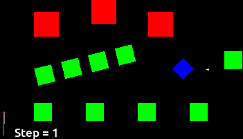

FPS = 10 There was one LOS loss between agent 1 and target at step 156

```r
# Set the working directory
setwd ("/home/pablo/Documents/Software Engineering/AI home exercise/Solution/output")
# Import the two agents with centralized control data-frame, importing the header and classifying non available data
twoAgentsWithCentralizedControl.data  = read.csv(file = "twoAgentsWithCentralCalculation.csv", header = TRUE, na.strings = "NaN")
# Display table with the required information
#kable(twoAgentsWithCentralizedControl.data,
#      label = "Two agents following target (with central control)")
```

## Algorithm for two agents following target (distributed)

- Build a list of possible NEXT locations for the (current) agent (working one second, and the other second, the second agent works) and target with SwissArmyKnife.PossibleMovements() given as input parameters: type of movement of person (1 meter constant, up to two meters, etc), current location and DSM map info, and receiving as output the list of possible NEXT movements, and current other agent location
- Filter from this list only the locations that have LOS between the agent and the target and also that will be at a minimum distance of the ALLOWED distance (10 meters in this case) with SwissArmyKnife.PossibleLineOfSightLocations() given as input parameters: list of possible NEXT movements from both agent and target, DSM map info, and minimum ALLOWED distance between both agent and target. The output received from this function is a new list having all the possible NEXT movements for agent, that will have LOS with target caring for the minimum allowed distance
- Rank the last list by minimum and maximum distance from agent to target, quantity of potential LOS with target, and distance to obstacle with the following functions: SwissArmyKnife.Ranking(). The idea of ranking, is that for all the potential movements, there will be a minimum and maximum (range) for each one of these variables. And therefore we will rank from 0% to 100%, according to where specific element is in the range of the possible NEXT movements.
- Once ranked these variables, we could use another function: SwissArmyKnife.RankingOrder() that will give a specific relative “weight” for each one of these variables: minimum distance from agent to target maximum distance from agent to target quantity of possible LOS situations minimum distance to obstacle distance to opposite location of other agent
- This function will order this list according to our requirements
- After a few verifications it has been seen, that the distance to obstacle should be with high relative weight, but once the distance between target and agent is more than 20, then the weight should fall more in the minimum distance to target (in order for the agent to reduce the distance)
- One of the agents will be “hard-coded” as master
- The slave agent will have, in addition to the regular rankings (like distance to obstacle, distance to target, etc), also the distance to the master agent opposite location (being the central point of this line, the target location)
- The ranking is different depending on the situation, and the kind of agent (master/slave)

- ```
    If agent is master, and the distance to target is more than 20 meters, then in the ranking give preference to potential movements that will reduce the distance between agent and target
  ```

- ```
    If agent is master, and the distance to target is less or equal to 20 meters, then in the ranking give preference to potential movements that will increase the distance between agent and closest obstacle
  ```

- ```
    If agent is slave, and the distance to target is more than 20 meters, then in the ranking give preference to potential movements that will reduce the distance between the slave agent and the opposite location to master agent, and also to target
  ```

- ```
    If agent is slave, and the distance to target is less or equal to 20 meters, then in the ranking give preference to potential movements that will reduce the distance between the slave agent and the opposite location to master agent and increase the distance to closest obstacle
  ```

- ```
    If both agents have lost LOS with target, and the distance to last known target location is more than 20 meters, then in the ranking give preference to potential movements that will reduce the distance between agent and last know target location
  ```

- ```
    If both agents have lost LOS with target, and the distance to last known target location is less or equal than 20 meters, then in the ranking give preference to potential movements that will increase the distance between agent and closest obstacle
  ```

- In case of LOS loss, we need to have the last target position seen (as the “target” position), modify temporarily the possibility to stay in place for the agent, so it could move towards the last seen position. Once there is again LOS, we need to bring back the regular configuration, and set the target position as the real target position

## 5) Working with two agents (distributed control)

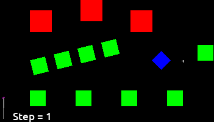

FPS = 10 There was one LOS loss between agent 1 and target at step 154 There was one LOS loss between both agents simultaneously and target at step 155 There was one LOS loss between agent 0 and target at step 156

We must take in account that in this case, the progress is slower than in previous one, up to 2 meters/second every 2 seconds